# BCB 520 - Project File

Author

Geraline Trossi-Torres

## DATA COLLECTION

The following data was gathered through an internet search, where the data is open to the public. The data contains the rank of overall sales, game title, platform of the video game release, year of game release, genre of the game, publisher of game, and sales in the millions for US, Europe, Japan, rest of world wide and total global sales.

### Data Set Type

#### **Flat Table - Video Games Sales**

We have a **Flat Table**, the **items** are the rows, wherein each row is the different types of games that has been released from 1983 - 2012. Each item (games) is described by attributes, which are put in columns. Those **attributes** represent: index, rank, game title, platform, year, genre, publisher, US, Europe, Japan, Rest of the Word, Global (total of sales), and reviews. For each column of the different countries represent the total sales from each one in terms of millions in sales.

```r
library(readxl)
my_df <- read_excel("Video Games Sales.xlsx")
knitr::kable(head(my_df,10))
```

| index | Rank | Game Title | Platform | Year | Genre | Publisher | North America | Europe | Japan | Rest of World | Global | Review |
| --- | --- | --- | --- | --- | --- | --- | --- | --- | --- | --- | --- | --- |
| 0 | 1 | Wii Sports | Wii | 2006 | Sports | Nintendo | 40.43 | 28.39 | 3.77 | 8.54 | 81.12 | 76.28 |
| 1 | 2 | Super Mario Bros. | NES | 1985 | Platform | Nintendo | 29.08 | 3.58 | 6.81 | 0.77 | 40.24 | 91.00 |
| 2 | 3 | Mario Kart Wii | Wii | 2008 | Racing | Nintendo | 14.50 | 12.22 | 3.63 | 3.21 | 33.55 | 82.07 |
| 3 | 4 | Wii Sports Resort | Wii | 2009 | Sports | Nintendo | 14.82 | 10.51 | 3.18 | 3.01 | 31.52 | 82.65 |
| 4 | 5 | Tetris | GB | 1989 | Puzzle | Nintendo | 23.20 | 2.26 | 4.22 | 0.58 | 30.26 | 88.00 |
| 5 | 6 | New Super Mario Bros. | DS | 2006 | Platform | Nintendo | 10.85 | 8.87 | 6.48 | 2.88 | 29.08 | 90.00 |
| 6 | 7 | Wii Play | Wii | 2006 | Misc | Nintendo | 13.83 | 9.11 | 2.93 | 2.84 | 28.71 | 61.64 |
| 7 | 8 | Duck Hunt | NES | 1984 | Shooter | Nintendo | 26.93 | 0.63 | 0.28 | 0.47 | 28.31 | 84.00 |
| 8 | 9 | New Super Mario Bros. Wii | Wii | 2009 | Platform | Nintendo | 13.35 | 6.48 | 4.66 | 2.25 | 26.75 | 88.18 |
| 9 | 10 | Nintendogs | DS | 2005 | Simulation | Nintendo | 9.02 | 10.81 | 1.93 | 2.73 | 24.50 | 85.00 |

```r
library(tidyverse)
```

## ATTRIBUTE TYPES

- **Categorical:** game title, platform, year, genre, publisher
- **Ordinal:** Index, ranking
- **Quantitative:** US (sales in millions), Europe (sales in millions), Japan (sales in millions), rest of the word (sales in millions), global (sales in millions), reviews in the sales

## WHAT DO I WANT FROM THIS DATA?

1. What was the highest video game sale from each country?
2. What was the most popular console (platform) for each country?
3. Which of the genres are most or/and less popular for each region?

## TASK ABSTRACTION

### Histogram Graph

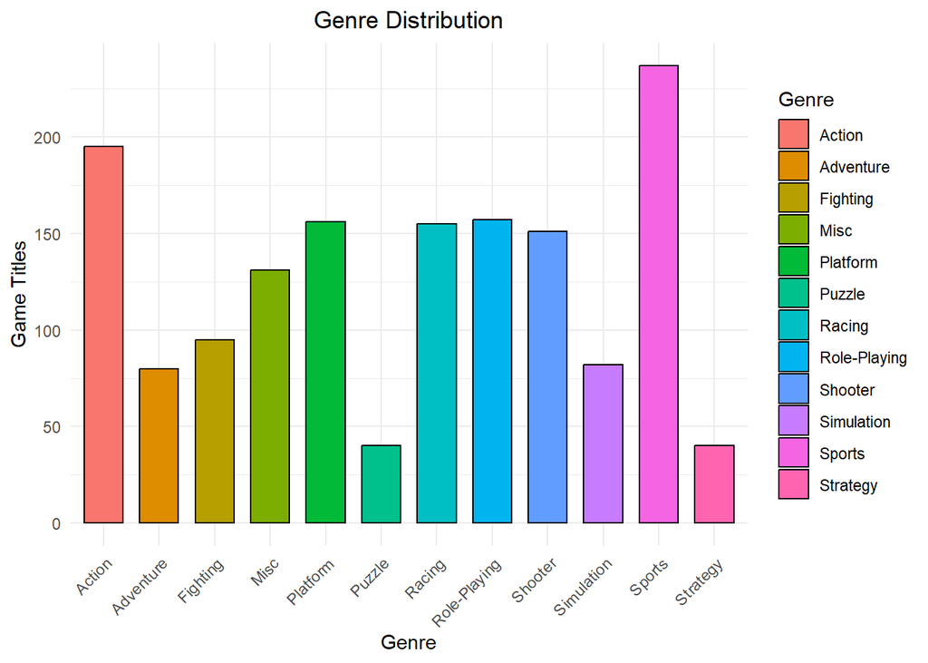

```r
title_genre<-my_df%>%
  select(Genre,`Game Title`)%>%
  group_by(Genre, `Game Title`)%>%
  summarise(count=n_distinct('Game Title'))%>%
  group_by(Genre) %>%
  summarise(TotalCount = sum(count))
ggplot(title_genre, aes(x = Genre, y=TotalCount,fill = Genre)) +
  geom_col(color = "black", width = 0.7) +
  ggtitle("Genre Distribution") +
  xlab("Genre") +
  ylab("Game Titles") +
  theme_minimal() +
  theme(plot.title = element_text(hjust = 0.5),
        axis.text.x = element_text(angle = 45, hjust = 1))
```

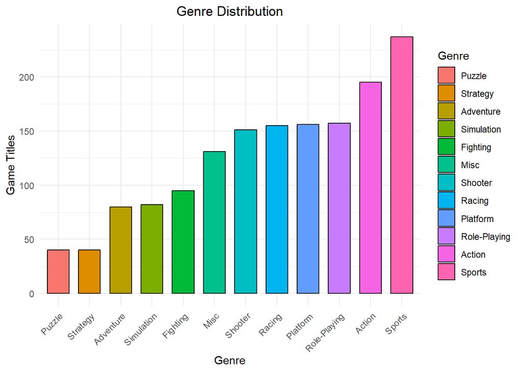

```r
library(ggplot2)

# Assuming title_genre is your data frame
title_genre$Genre <- reorder(title_genre$Genre, title_genre$TotalCount)

ggplot(data = title_genre, aes(x = Genre, y = TotalCount, fill = Genre)) +
  geom_col(color = "black", width = 0.7) +
  ggtitle("Genre Distribution") +
  xlab("Genre") +
  ylab("Game Titles") +
  theme_minimal() +
  theme(plot.title = element_text(hjust = 0.5),
        axis.text.x = element_text(angle = 45, hjust = 1))
```

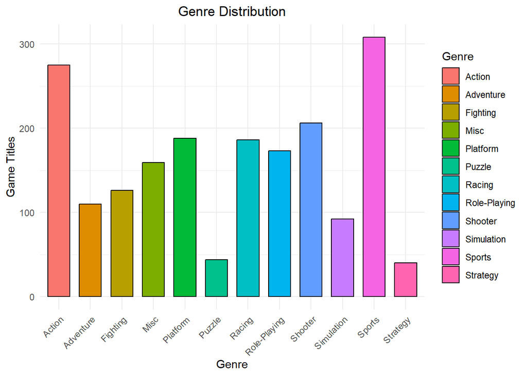

```r
ggplot(my_df, aes(x = Genre, fill = Genre)) +
  geom_bar(color = "black", width = 0.7) +
  ggtitle("Genre Distribution") +
  xlab("Genre") +
  ylab("Game Titles") +
  theme_minimal() +
  theme(plot.title = element_text(hjust = 0.5),
        axis.text.x = element_text(angle = 45, hjust = 1))
```

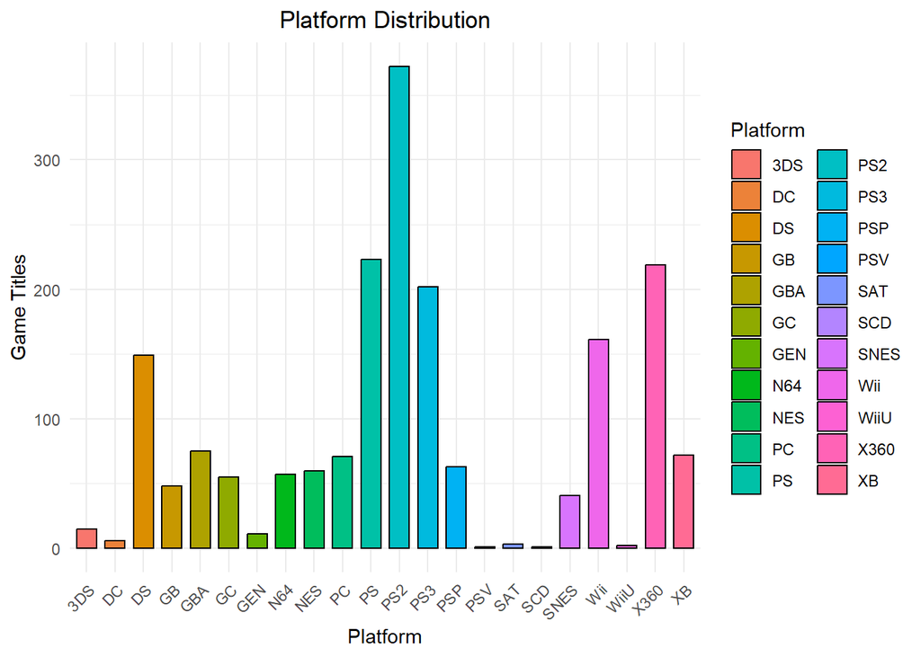

```r
ggplot(my_df, aes(x = Platform, fill = Platform)) +
  geom_bar(color = "black", width = 0.7) +
  ggtitle("Platform Distribution") +
  xlab("Platform") +
  ylab("Game Titles") +
  theme_minimal() +
  theme(plot.title = element_text(hjust = 0.5),
        axis.text.x = element_text(angle = 45, hjust = 1))
```

### Scatter Plot

[figure not shown]

```r
ggplot(my_df, aes(x = Platform, y = 'North America')) +
  geom_point(color = "darkblue") +
  ggtitle("Scatter Plot: Platform vs. North America") +
  xlab("Platform") +
  ylab("North America") +
  theme_minimal() +
  theme(plot.title = element_text(hjust = 0.5),
        axis.text.x = element_text(angle = 45, hjust = 1),
        axis.title.x = element_text(margin = margin(t = 10)))
```

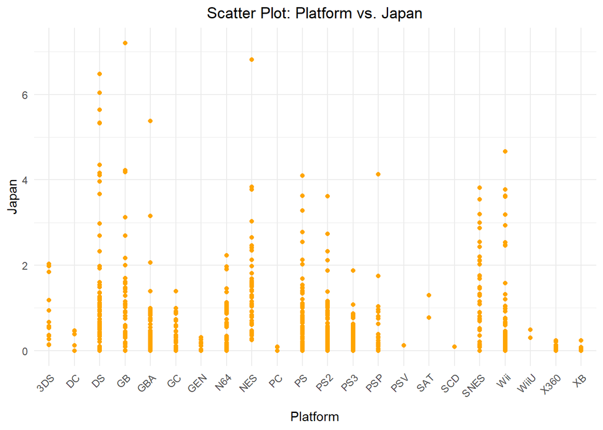

```r
ggplot(my_df, aes(x = Platform, y = Japan)) +
  geom_point(color = "orange") +
  ggtitle("Scatter Plot: Platform vs. Japan") +
  xlab("Platform") +
  ylab("Japan") +
  theme_minimal() +
  theme(plot.title = element_text(hjust = 0.5),
        axis.text.x = element_text(angle = 45, hjust = 1),
        axis.title.x = element_text(margin = margin(t = 10)))
```

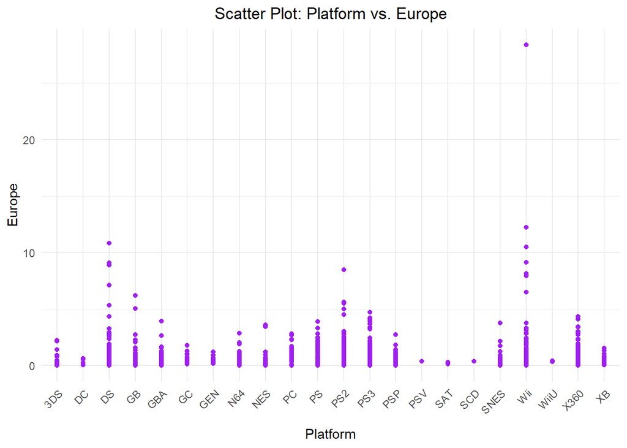

```r
ggplot(my_df, aes(x = Platform, y = Europe)) +
  geom_point(color = "purple") +
  ggtitle("Scatter Plot: Platform vs. Europe") +
  xlab("Platform") +
  ylab("Europe") +
  theme_minimal() +
  theme(plot.title = element_text(hjust = 0.5),
        axis.text.x = element_text(angle = 45, hjust = 1),
        axis.title.x = element_text(margin = margin(t = 10)))
```